# Machine Learning Models - Classification - League of Legends Pro Players’ Positions

# 5 Extracting Insights

Analysis using the most relevant variables for the classification, jointly with the predictions of the models. Using a subset of the most relevant variables is an efficient way of extracting insights. If time allows, we can also use the rest of the predictors.

## 5.1 Defining the most relevant variables

First, we take a look at the variable importance scores.

```r
print(rf.importance); print(boost.importance); print(nn.single.importance)
```

```
##                   ADC     JUNGLE       MID   SUPPORT       TOP
## kda          5.450505   6.172666  7.641242  5.226514  9.934108
## avg_kills   23.574298  15.960868 35.203036 18.976965 16.773658
## avg_deaths   5.520654   4.321121  3.200325  3.138112  4.918362
## avg_assists  5.304227  11.164412 16.165875 13.384082 -2.146616
## csm         84.179707 140.199120 51.984550 55.061459 84.577354
##             MeanDecreaseAccuracy MeanDecreaseGini
## kda                     16.25391         57.83954
## avg_kills               34.48554        156.20616
## avg_deaths              10.43784         49.23684
## avg_assists             18.36293         78.36128
## csm                    128.89776        297.69246
```

```
## gbm variable importance
##
##             Overall
## csm         100.000
## avg_kills    11.046
## avg_assists   4.216
## kda           2.514
## avg_deaths    0.000
```

```
## nnet variable importance
##
##   variables are sorted by maximum importance across the classes
##               Overall       ADC  JUNGLE       MID   SUPPORT       TOP
## csm         1.000e+02 1.000e+02 100.000 1.000e+02 1.000e+02 1.000e+02
## avg_kills   1.788e+01 1.788e+01  17.879 1.788e+01 1.788e+01 1.788e+01
## avg_assists 8.212e+00 8.212e+00   8.212 8.212e+00 8.212e+00 8.212e+00
## kda         1.740e+00 1.740e+00   1.740 1.740e+00 1.740e+00 1.740e+00
## avg_deaths  6.672e-16 6.672e-16   0.000 6.672e-16 6.672e-16 6.672e-16
```

Define a vector of the most important variables.

```r
important.vars = c("avg_deaths","csm","avg_kills"); print("The variables that are more relevant for predicting are"); print(important.vars)
```

```
## [1] "The variables that are more relevant for predicting are"
```

[output not shown]

```r
# If desired, we can use all the predictors in the analysis with the code line --> important.vars = colnames(test[,2:ncol(test)])
```

## 5.2 Summary statistics, clustered by predictions

```r
groups.summaries = "target.var" # Defines the cluster level (which can also be set to a non-response variable)
predictors.of.interest = important.vars
for (predictor in predictors.of.interest){
  means = aggregate(test[,predictor], list(classifications), mean); medians = aggregate(test[,predictor], list(classifications), median)
  sds = aggregate(test[,predictor], list(classifications), sd); maxs = aggregate(test[,predictor], list(classifications), max)
  mins = aggregate(test[,predictor], list(classifications), min)
  summary.stats = data.frame(means,medians[,2],sds[,2],maxs[,2],mins[,2])
  colnames(summary.stats) = c(groups.summaries,"mean","median","standard dev","max","min")
  print(sprintf("Summary statistics of %s by %s are", predictor, groups.summaries)); print(summary.stats); cat("\n")
}
```

```
## [1] "Summary statistics of avg_deaths by target.var are"
##   target.var     mean median standard dev max min
## 1        ADC 1.845890    1.8    0.5683766 4.1 0.8
## 2     JUNGLE 2.555828    2.6    0.5319540 4.1 1.4
## 3        MID 2.342069    2.3    0.5669937 3.7 1.0
## 4    SUPPORT 2.601190    2.5    0.6464077 4.6 1.4
## 5        TOP 2.535754    2.5    0.5350164 3.9 1.3
##
## [1] "Summary statistics of csm by target.var are"
##   target.var     mean median standard dev  max min
## 1        ADC 9.402055    9.5    0.8453907 10.7 4.4
## 2     JUNGLE 4.828221    4.8    0.5951978  7.0 3.6
## 3        MID 8.580000    8.6    0.4531679  9.6 6.6
## 4    SUPPORT 1.241667    1.2    0.4190689  4.7 0.5
## 5        TOP 8.018436    8.0    0.6475935  9.7 6.4
##
## [1] "Summary statistics of avg_kills by target.var are"
##   target.var      mean median standard dev max min
## 1        ADC 3.4472603    3.4    0.8442254 6.4 1.3
## 2     JUNGLE 2.2374233    2.1    0.6580073 4.5 0.8
## 3        MID 3.3806897    3.4    0.6656551 5.4 1.9
## 4    SUPPORT 0.7136905    0.7    0.2628553 1.7 0.1
## 5        TOP 2.2145251    2.2    0.5820452 4.1 1.0
```

## 5.3 Correlation analysis, clustered by predictions

```r
require(ggplot2); require(GGally)
```

The following plot clusters by leves of prediction using different colors.

```r
groups = as.factor(classifications) # Clusters the graphs by predictions.
plot.ggpairs = ggpairs(test[,c(target.var,important.vars)], ggplot2::aes(colour=groups), diag = list(discrete="barDiag", lower = list(continuous = wrap("smooth", alpha = 0.3, size=0.1), discrete = "blank", combo="blank"), continuous = wrap("densityDiag", alpha=0.4)))
```

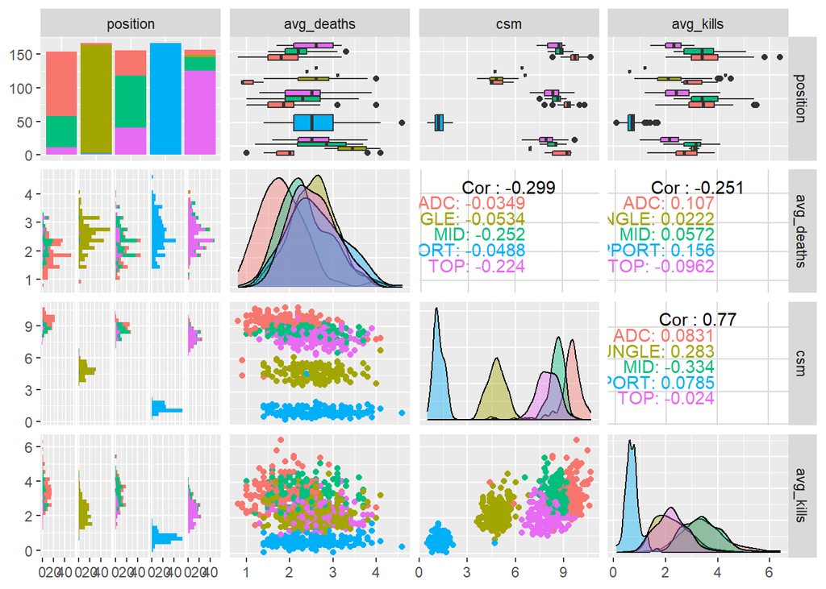

```r
print(plot.ggpairs)
```

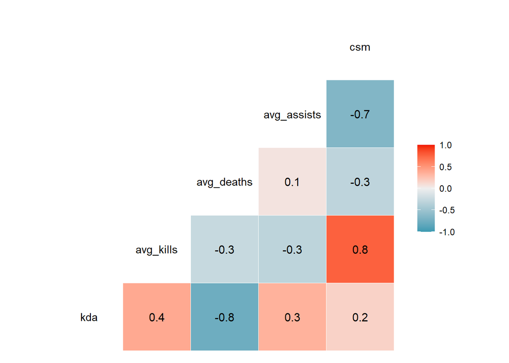

```r
ggcorr(test, palette = "RdBu", label = TRUE)
```

```r
overall.end.time = Sys.time(); overall.total.time = overall.end.time - overall.start.time
sprintf("Overall, it takes %.2f minutes to complete all the code in a computer with an Intel(R) Core(TM) i7-4510U CPU @ 2.00GHz 2.60 GHz processor and 16GB of RAM.", overall.total.time)
```

```
## [1] "Overall, it takes 1.41 minutes to complete all the code in a computer with an Intel(R) Core(TM) i7-4510U CPU @ 2.00GHz 2.60 GHz processor and 16GB of RAM."
```